# PML Project

Subhashish Panda

December 26, 2018

### Executive Summary

In this project, the author has tested four algorithms: Trees, Naive Bayes, Support Vector Machine, and Random Forest in predicting the classe of the test dataset. Cross validation was performed through 10 folds from the training dataset. Out of four, only random forest generated a higher accuracy based on the confusionMatrix function of the caret package. With the accuracy as basis of choosing the model, the author concluded to use the random forest in predicting the classe of test dataset. The prediction resulted to a 95% score in the prediction quiz thereby, providing proof that the author has correctly chosen the best model for the prediction of test data.

### Building the model and Cross Validation

In this case, the author will predict the “Classe” for each observation in the testing dataset. There are a number of classification algorithms available in the caret package. With this, the accuracy shall be the basis of choosing the model in predicting the classe of the test dataset. The following classification algorithms that were performed and analyzed are: Trees, Naive Bayes, Support Vector Machine, and Random Forest.

Cross validation is performed through 10 folds. The author chose 10 folds so that, the model will have less variability and less biased.

```r
# Load the training and testing datasets
training <- read.csv("pml-training.csv")
testing <- read.csv("pml-testing.csv")

# Subsetting the datasets (only the accelerometers and classe)
library(plyr)
library(dplyr)
training <- select(training, classe, grep("accel", names(training)))
testing <- select(testing, grep("accel", names(testing)))

# Remove variables with no values
training <- training[ , colSums(!is.na(training)) == nrow(training)]
testing <- testing[ , colSums(!is.na(testing)) == nrow(testing)]

# Building the model
library(caret)
library(randomForest)
library(kernlab)

        # Trees
        model_1 <- train(classe ~., data = training, method="rpart", trControl = trainControl(method = "cv", number = 10, verboseIter = TRUE))
        accuracy_1 <- confusionMatrix(predict(model_1, training), training$classe)


        # Naive Bayes
        model_2 <- train(classe ~., data = training, method="nb", trControl = trainControl(method = "cv", number = 10, verboseIter = TRUE))
        accuracy_2 <- confusionMatrix(predict(model_2, training), training$classe)

        # Linear SVC
        model_3 <- train(classe ~., data = training, method="svmLinear", trControl = trainControl(method = "cv", number = 10, verboseIter = TRUE))
        accuracy_3 <- confusionMatrix(predict(model_3, training), training$classe)

        # Random Forest
        model_4 <- train(classe ~., data = training, method="rf", trControl = trainControl(method = "cv", number = 10, verboseIter = TRUE))
        accuracy_4 <- confusionMatrix(predict(model_4, training), training$classe)
```

### Analysis & Results

```r
# Comparing the accuracy for each models
data.frame(model=c("Trees", "Naive Bayes", "Linear SVC", "Random Forest"),
           accuracy = c(accuracy_1[[3]][1], accuracy_2[[3]][1], accuracy_3[[3]][1], accuracy_4[[3]][1]))
```

```
##           model  accuracy
## 1         Trees 0.4195801
## 2   Naive Bayes 0.5806238
## 3    Linear SVC 0.5514728
## 4 Random Forest 1.0000000
```

The graph of Random Forest is presented as follows:

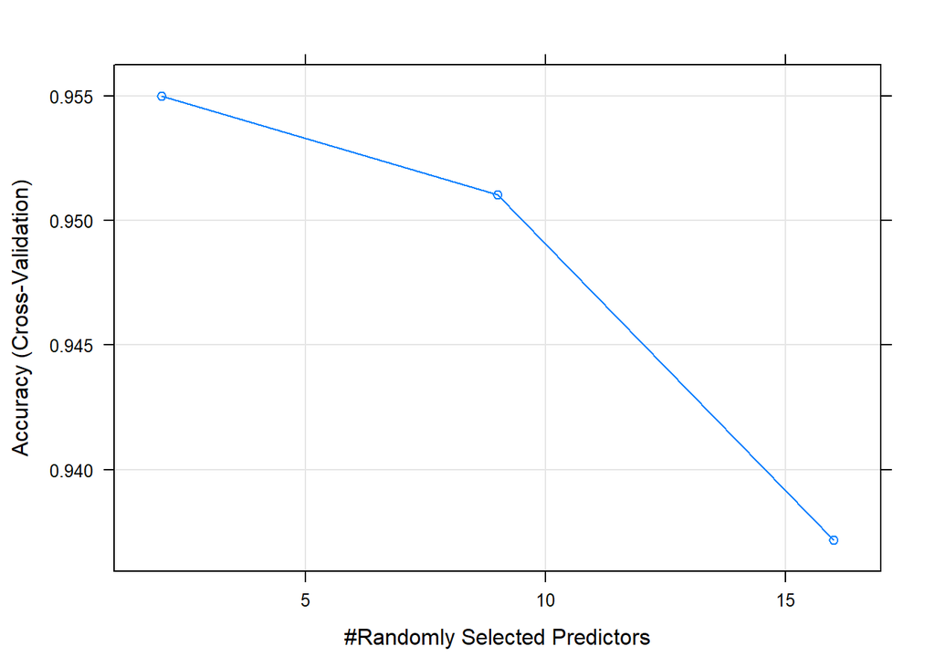

```r
# Accuracy (Cross-Validation)
plot(model_4)
```

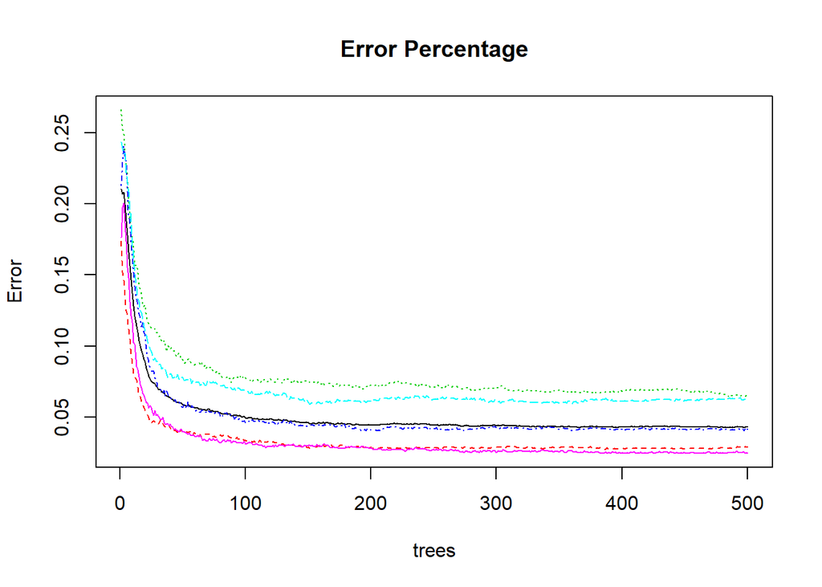

```r
# Error
plot(model_4$finalModel, main = "Error Percentage")
```

The prediction for the test dataset shows the following:

```r
data.frame(Observation = 1:20, Classe = predict(model_4, testing))
```

```
##    Observation Classe
## 1            1      B
## 2            2      A
## 3            3      C
## 4            4      A
## 5            5      A
## 6            6      E
## 7            7      D
## 8            8      B
## 9            9      A
## 10          10      A
## 11          11      B
## 12          12      C
## 13          13      B
## 14          14      A
## 15          15      E
## 16          16      E
## 17          17      A
## 18          18      B
## 19          19      B
## 20          20      B
```